# Antimicrobial resistance surveillance analysis in R

Pathogen distribution, antibiograms, resistance by ward, trends and MDR classification

Ahmed Hamdy

2026-10-28

## 1. Question and data

**Question:** in a hospital isolate collection, which bacteria are most common, how resistant are they to key antibiotics, does resistance differ between wards and over time, and what share of isolates are multidrug-resistant?

**Data:** the `example_isolates` dataset shipped with the `AMR` package: 2,000 bacterial isolates with their antibiograms (susceptibility results as S, I or R), plus date, patient, age, gender and ward. It is an example dataset for the package, so the results illustrate the workflow and should not be read as real surveillance findings.

```r
library(AMR)
library(dplyr)
library(ggplot2)
```

```r
iso <- example_isolates
iso$species <- mo_name(iso$mo)
iso$gram <- mo_gramstain(iso$mo)
iso$year <- as.integer(format(iso$date, "%Y"))

dim(iso)
```

```
## [1] 2000   49
```

```r
range(iso$date)
```

```
## [1] "2002-01-02" "2017-12-28"
```

```r
table(iso$ward)
```

```
##
##   Clinical        ICU Outpatient
##       1234        646        120
```

## 2. Keep one isolate per patient episode

Surveillance counts should not include repeat isolates from the same patient, because they inflate resistance rates. `first_isolate()` keeps the first isolate of each patient and species episode.

```r
iso$first <- first_isolate(iso)
fi <- iso[which(iso$first), ]
cat("All isolates:", nrow(iso), "\n")
```

```
## All isolates: 2000
```

```r
cat("First isolates kept:", nrow(fi), "\n")
```

```
## First isolates kept: 1387
```

## 3. Which pathogens are most common?

```r
top_species <- fi %>%
  count(species, sort = TRUE) %>%
  mutate(percent = round(100 * n / sum(n), 1)) %>%
  head(10)
top_species
```

```
## # A tibble: 10 × 3
##    species                                      n percent
##    <chr>                                    <int>   <dbl>
##  1 Escherichia coli                           271    19.5
##  2 Coagulase-negative Staphylococcus (CoNS)   270    19.5
##  3 Staphylococcus epidermidis                 147    10.6
##  4 Staphylococcus aureus                      122     8.8
##  5 Streptococcus pneumoniae                    86     6.2
##  6 Staphylococcus hominis                      74     5.3
##  7 Klebsiella pneumoniae                       37     2.7
##  8 Enterococcus faecalis                       23     1.7
##  9 Proteus mirabilis                           20     1.4
## 10 Staphylococcus capitis                      20     1.4
```

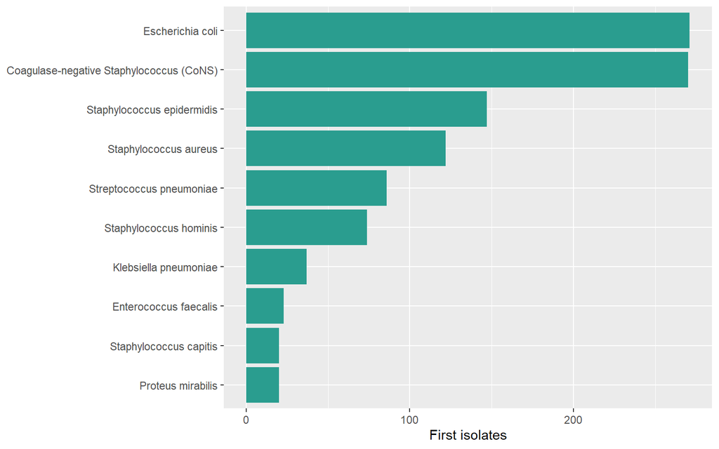

```r
ggplot(top_species, aes(x = reorder(species, n), y = n)) +
  geom_col(fill = "#2a9d8f") +
  coord_flip() +
  labs(x = NULL, y = "First isolates")
```

```r
fi %>%
  count(gram) %>%
  mutate(percent = round(100 * n / sum(n), 1))
```

```
## # A tibble: 3 × 3
##   gram              n percent
##   <chr>         <int>   <dbl>
## 1 Gram-negative   441    31.8
## 2 Gram-positive   933    67.3
## 3 <NA>             13     0.9
```

## 4. Antibiograms

A traditional antibiogram gives the percentage of isolates susceptible (S or I) per species and antibiotic. Combinations that cover more isolates are useful for empiric therapy.

```r
antibiogram(fi, antibiotics = c("AMX", "AMC", "CIP", "GEN", "TZP"))
```

| Pathogen | Amoxicillin | Amoxicillin/clavulanic acid | Ciprofloxacin | Gentamicin | Piperacillin/tazobactam |
| --- | --- | --- | --- | --- | --- |
| CoNS | 8% (4-14%,N=115) | 60% (54-66%,N=268) | 75% (69-81%,N=223) | 88% (83-91%,N=267) | 30% (15-49%,N=30) |
| *E. coli* | 49% (42-56%,N=229) | 86% (81-90%,N=271) | 86% (82-90%,N=265) | 97% (94-99%,N=268) | 94% (91-97%,N=243) |
| *K. pneumoniae* | 0% (0-9%,N=37) | 89% (75-97%,N=37) | 97% (85-100%,N=35) | 92% (78-98%,N=37) | 88% (73-97%,N=34) |
| *S. aureus* | 6% (2-15%,N=67) | 99% (96-100%,N=122) | 90% (83-95%,N=102) | 99% (95-100%,N=121) | NA |
| *S. epidermidis* | 1% (0-7%,N=76) | 48% (39-56%,N=143) | 65% (56-73%,N=120) | 80% (73-86%,N=142) | NA |
| *S. hominis* | NA | 63% (51-74%,N=73) | 80% (68-89%,N=64) | 92% (83-97%,N=73) | NA |
| *S. pneumoniae* | 100% (96-100%,N=82) | 100% (96-100%,N=82) | NA | 0% (0-4%,N=86) | 100% (96-100%,N=82) |

Combination antibiogram by Gram stain: does adding an aminoglycoside to piperacillin/tazobactam improve coverage?

```r
antibiogram(fi, antibiotics = c("TZP", "TZP+GEN", "TZP+TOB"),
            mo_transform = "gramstain")
```

| Pathogen | Piperacillin/tazobactam | Piperacillin/tazobactam + Gentamicin | Piperacillin/tazobactam + Tobramycin |
| --- | --- | --- | --- |
| Gram-negative | 86% (83-90%,N=389) | 98% (96-99%,N=411) | 98% (96-99%,N=411) |
| Gram-positive | 85% (80-89%,N=251) | 98% (96-99%,N=788) | 96% (93-97%,N=407) |

## 5. Resistance in *Escherichia coli* by ward

```r
ecoli <- fi %>% filter(species == "Escherichia coli")
abx <- c("AMX", "AMC", "CIP", "GEN", "SXT")

res_tbl <- bind_rows(lapply(abx, function(ab) {
  ecoli %>%
    mutate(r = as.character(.data[[ab]])) %>%
    filter(!is.na(r)) %>%
    group_by(ward) %>%
    summarise(antibiotic = ab, tested = n(), resistant = sum(r == "R"),
              .groups = "drop")
}))

res_tbl <- res_tbl %>%
  rowwise() %>%
  mutate(pct = 100 * resistant / tested,
         lo = 100 * prop.test(resistant, tested)$conf.int[1],
         hi = 100 * prop.test(resistant, tested)$conf.int[2]) %>%
  ungroup()

res_tbl %>% mutate(across(c(pct, lo, hi), ~ round(.x, 1)))
```

```
## # A tibble: 15 × 7
##    ward       antibiotic tested resistant   pct    lo    hi
##    <chr>      <chr>       <int>     <int> <dbl> <dbl> <dbl>
##  1 Clinical   AMX           155        77  49.7  41.6  57.8
##  2 ICU        AMX            58        32  55.2  41.6  68
##  3 Outpatient AMX            16         8  50    28    72
##  4 Clinical   AMC           180        24  13.3   8.9  19.4
##  5 ICU        AMC            74        13  17.6  10    28.5
##  6 Outpatient AMC            17         2  11.8   2.1  37.7
##  7 Clinical   CIP           174        25  14.4   9.7  20.7
##  8 ICU        CIP            74         8  10.8   5.1  20.7
##  9 Outpatient CIP            17         3  17.6   4.7  44.2
## 10 Clinical   GEN           177         5   2.8   1     6.8
## 11 ICU        GEN            74         2   2.7   0.5  10.3
## 12 Outpatient GEN            17         1   5.9   0.3  30.8
## 13 Clinical   SXT           179        63  35.2  28.3  42.7
## 14 ICU        SXT            74        25  33.8  23.5  45.8
## 15 Outpatient SXT            17         7  41.2  19.4  66.5
```

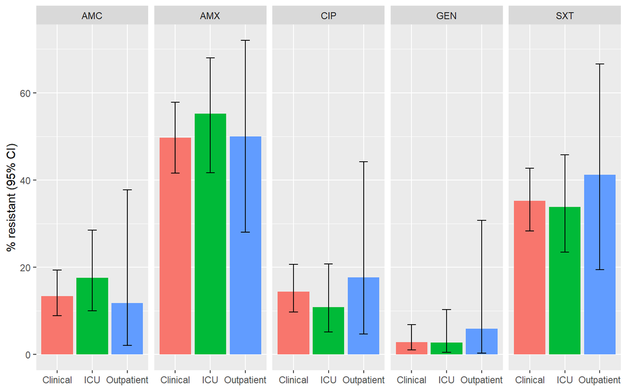

```r
ggplot(res_tbl, aes(x = ward, y = pct, fill = ward)) +
  geom_col() +
  geom_errorbar(aes(ymin = lo, ymax = hi), width = 0.25) +
  facet_wrap(~antibiotic, nrow = 1) +
  labs(x = NULL, y = "% resistant (95% CI)") +
  theme(legend.position = "none")
```

## 6. Resistance trend over time

Ciprofloxacin resistance in *E. coli*, modelled with logistic regression on calendar year. The odds ratio is per additional year.

```r
trend_df <- ecoli %>%
  mutate(r = as.character(CIP)) %>%
  filter(!is.na(r)) %>%
  mutate(resistant = as.integer(r == "R"),
         year_c = year - min(year))

yearly <- trend_df %>%
  group_by(year) %>%
  summarise(tested = n(), pct_resistant = 100 * mean(resistant))
yearly
```

```
## # A tibble: 16 × 3
##     year tested pct_resistant
##    <int>  <int>         <dbl>
##  1  2002     11          9.09
##  2  2003     14          0
##  3  2004     12          0
##  4  2005     15          6.67
##  5  2006     18         16.7
##  6  2007     19          0
##  7  2008     17          5.88
##  8  2009     20         20
##  9  2010     14         28.6
## 10  2011     22          4.55
## 11  2012     11         18.2
## 12  2013     13         23.1
## 13  2014     20         15
## 14  2015     14         28.6
## 15  2016     22         18.2
## 16  2017     23         21.7
```

```r
fit_trend <- glm(resistant ~ year_c, data = trend_df, family = binomial)
trend_or <- exp(cbind(OR_per_year = coef(fit_trend), confint.default(fit_trend)))
round(trend_or, 3)
```

```
##             OR_per_year 2.5 % 97.5 %
## (Intercept)       0.054 0.022  0.133
## year_c            1.126 1.036  1.225
```

```r
summary(fit_trend)$coefficients
```

```
##               Estimate Std. Error   z value     Pr(>|z|)
## (Intercept) -2.9103551 0.45452144 -6.403120 1.522338e-10
## year_c       0.1188976 0.04268339  2.785571 5.343352e-03
```

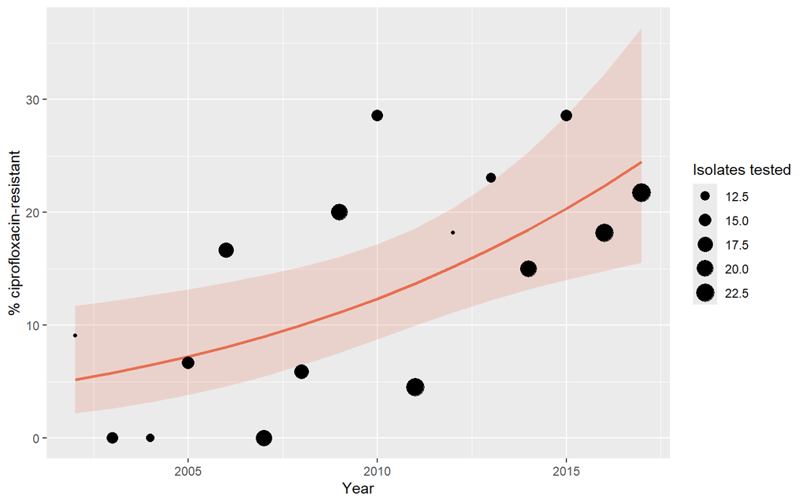

```r
# Fitted curve with 95% CI from the logistic model (on the link scale)
newd <- data.frame(year_c = 0:max(trend_df$year_c))
pr <- predict(fit_trend, newdata = newd, type = "link", se.fit = TRUE)
newd$year <- newd$year_c + min(trend_df$year)
newd$fit <- 100 * plogis(pr$fit)
newd$lo <- 100 * plogis(pr$fit - 1.96 * pr$se.fit)
newd$hi <- 100 * plogis(pr$fit + 1.96 * pr$se.fit)

ggplot(yearly, aes(x = year, y = pct_resistant)) +
  geom_ribbon(data = newd, aes(x = year, ymin = lo, ymax = hi),
              inherit.aes = FALSE, fill = "#e76f51", alpha = 0.2) +
  geom_line(data = newd, aes(x = year, y = fit),
            inherit.aes = FALSE, colour = "#e76f51", linewidth = 1) +
  geom_point(aes(size = tested)) +
  labs(x = "Year", y = "% ciprofloxacin-resistant", size = "Isolates tested")
```

## 7. Factors associated with ciprofloxacin resistance

Age is split at 65 years. A first version with three age groups gave unstable estimates (odds ratios in the hundreds of thousands), a sign of quasi-complete separation: some small groups had no resistant isolates, so the model could not estimate an odds ratio. The cross-tabulation below shows the counts.

```r
trend_df$age_group <- factor(ifelse(trend_df$age >= 65, "65+", "<65"),
                             levels = c("<65", "65+"))
table(age_group = trend_df$age_group, resistant = trend_df$resistant)
```

```
##          resistant
## age_group   0   1
##       <65  43   3
##       65+ 186  33
```

```r
table(ward = trend_df$ward, resistant = trend_df$resistant)
```

```
##             resistant
## ward           0   1
##   Clinical   149  25
##   ICU         66   8
##   Outpatient  14   3
```

```r
fit <- glm(resistant ~ ward + gender + age_group, data = trend_df,
           family = binomial)
round(exp(cbind(OR = coef(fit), confint.default(fit))), 2)
```

```
##                  OR 2.5 % 97.5 %
## (Intercept)    0.06  0.02   0.21
## wardICU        0.76  0.33   1.80
## wardOutpatient 1.32  0.35   5.00
## genderM        1.67  0.82   3.43
## age_group65+   2.42  0.71   8.32
```

## 8. Multidrug-resistant organisms (MDR)

`mdro()` classifies each isolate by international consensus definitions (default: Magiorakos et al. 2012, CMI).

```r
fi$mdr <- mdro(fi)
```

[output not shown]

```
##
## => Found 81 MDRs/XDRs/PDRs out of 1387 isolates (5.8%)
##    (another 13 isolates had no test results)
##
## Rerun with `verbose = TRUE` to retrieve detailed info and reasons for every MDRO classification.
```

```r
table(fi$mdr)
```

```
##
##                         Negative       Multi-drug-resistant (MDR)
##                             1160                               81
## Extensively drug-resistant (XDR)          Pandrug-resistant (PDR)
##                                0                                0
```

```r
mdr_ward <- fi %>%
  count(ward, mdr) %>%
  group_by(ward) %>%
  mutate(percent = round(100 * n / sum(n), 1)) %>%
  ungroup()
mdr_ward
```

```
## # A tibble: 9 × 4
##   ward       mdr                            n percent
##   <chr>      <ord>                      <int>   <dbl>
## 1 Clinical   Negative                     715    84.1
## 2 Clinical   Multi-drug-resistant (MDR)    48     5.6
## 3 Clinical   <NA>                          87    10.2
## 4 ICU        Negative                     358    81
## 5 ICU        Multi-drug-resistant (MDR)    31     7
## 6 ICU        <NA>                          53    12
## 7 Outpatient Negative                      87    91.6
## 8 Outpatient Multi-drug-resistant (MDR)     2     2.1
## 9 Outpatient <NA>                           6     6.3
```

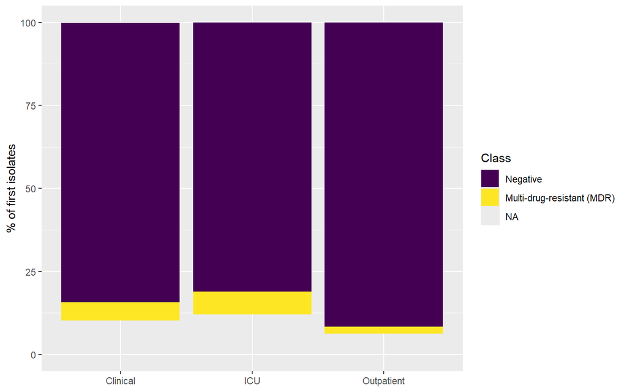

```r
ggplot(mdr_ward, aes(x = ward, y = percent, fill = mdr)) +
  geom_col() +
  labs(x = NULL, y = "% of first isolates", fill = "Class")
```

## 9. Export

```r
dir.create("results", showWarnings = FALSE)
write.csv(res_tbl, "results/ecoli_resistance_by_ward.csv", row.names = FALSE)
write.csv(yearly, "results/ecoli_cip_resistance_by_year.csv", row.names = FALSE)
write.csv(mdr_ward, "results/mdr_by_ward.csv", row.names = FALSE)
```

## 10. Limitations

- The data are an example dataset shipped with a software package, so the numbers illustrate the workflow and are not real surveillance results.
- Some species-antibiotic-ward groups have few isolates, so confidence intervals are wide.
- The trend model is a simple logistic regression and ignores changes in testing practice over time.
- Resistance is reported for first isolates only; clinical breakpoints and intrinsic resistance rules follow the `AMR` package defaults.